# Ejercicios Geometría de la muestra

Jorge de la Vega

29 de agosto de 2018

# Ejercicios

1. Distancia entre poblaciones de datos

El concepto más común de distancia entre dos puntos es la distancia euclidena: si **x** y **y** son dos vectores entonces la distancia euclideana entre es

$$||x-y|| = (x-y)'(x-y) = \sqrt{(x_1-y_1)^2 + \cdots + (x_p-y_p)^2 }$$

Otra medida de distancia es la métrica de Minkowski, dada por

$$d_M(x,y) = \left( \sum_{i=1}^p |x_i-y_i|^m \right)^{1/m}$$

Esta métrica incluye claramente a la euclideana ($m=2$), y cuando $m=1$ es la distancia conocida como “ciudad” o “Manhattan”. (Pregunta a los avanzados: ¿qué pasa cuando $m \rightarrow \infty$?)

$$\delta_A(x,y) = \sqrt{(x-y)'A(x-y)}$$

En particular, si ${\bf A} = {\bf \Sigma}^{-1}$ esta distancia tomará en cuenta la variabilidad de una muestra para definir la distancia entre dos puntos en relación a la posición de esos puntos en la muestra.

Consideren las siguientes gráficas de puntos simulados en cada caso, de dos distribuciones normales bivariadas ${\bf X}$ y ${\bf Y}$ con diferentes medias y covarianzas en cada caso, de la siguiente manera:

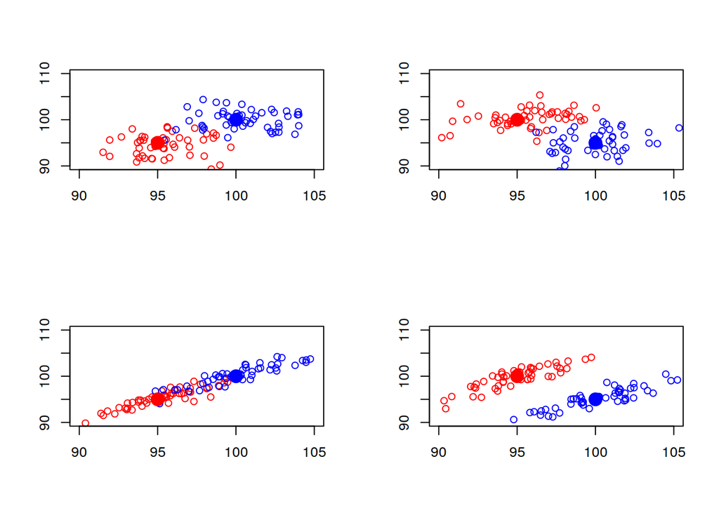

```r
library(MASS) # mvrnorm para generar una muestra normal multivariada (los que tomaron simulación, conocen más formas)
#Definimos parámetros para medias y covarianzas
mu1 <- c(95,95)
mu2 <- c(100,100)
mu3 <- c(95,100)
mu4 <- c(100,95)
Sigma1 <- 5*diag(2)
Sigma2 <- matrix(5*c(1,0.9,0.9,1),ncol=2)

par(mfrow=c(2,2))

#Gráfica 1 : con X~N(mu1,Sigma1), Y~N(mu2,Sigma1)
plot(mvrnorm(50, mu1, Sigma1), col = "red", xlab = "", ylab = "", xlim = c(90,105), ylim = c(90,110))
points(mvrnorm(50, mu2, Sigma1), col = "blue")
points(x = mu1[1], y = mu1[2], col = "red", pch = 19, cex = 2)
points(x = mu2[1], y = mu2[2], col = "blue", pch = 19, cex = 2)

#Gráfica 2: con X~N(mu3,Sigma1), Y~N(mu4,Sigma1)
plot(mvrnorm(50, mu3, Sigma1), col = "red", xlab = "", ylab = "", xlim = c(90,105), ylim = c(90,110))
points(mvrnorm(50, mu4, Sigma1), col = "blue")
points(x = mu3[1], y = mu3[2], col = "red", pch = 19, cex = 2)
points(x = mu4[1], y = mu4[2], col = "blue", pch = 19, cex = 2)

#Gráfica 3: con X~N(mu1,Sigma2), Y~N(mu2,Sigma2)
plot(mvrnorm(50, mu1, Sigma2), col = "red", xlab = "", ylab = "", xlim = c(90,105), ylim = c(90,110))
points(mvrnorm(50, mu2, Sigma2), col = "blue")
points(x = mu1[1], y = mu1[2], col = "red", pch = 19, cex = 2)
points(x = mu2[1], y = mu2[2], col = "blue", pch = 19, cex = 2)

#Gráfica 4: con X~N(mu3,Sigma2), Y~N(mu3,Sigma2)
plot(mvrnorm(50, mu3, Sigma2), col = "red", xlab = "", ylab = "", xlim = c(90,105), ylim = c(90,110))
points(mvrnorm(50, mu4, Sigma2), col = "blue")
points(x = mu3[1], y = mu3[2], col = "red", pch = 19, cex = 2)
points(x = mu4[1], y = mu4[2], col = "blue", pch = 19, cex = 2)
```

```r
norma <- function(x,y) as.numeric(sqrt(t(x-y)%*%(x-y)))
norma(mu1, mu2)
```

```
## [1] 7.071068
```

```r
norma(mu3, mu4)
```

```
## [1] 7.071068
```

```r
Minkowski <- function(x,y,m=1)(sum(abs(x-y)^m))^(1/m)
Minkowski(mu1,mu2,m=200)
```

```
## [1] 5.017359
```

```r
Minkowski(mu3,mu4)
```

```
## [1] 10
```

Sin embargo, en la distancia de Mahalanobis, obtenemos diferencias entre las poblaciones: mientras menos traslape haya entre las poblaciones, mayor es la distancia de Mahalanobis.

```r
sqrt(mahalanobis(mu1, mu2, cov = Sigma1))
```

```
## [1] 3.162278
```

```r
sqrt(mahalanobis(mu3, mu4, cov = Sigma1))
```

```
## [1] 3.162278
```

```r
sqrt(mahalanobis(mu1, mu2, cov = Sigma2))
```

```
## [1] 2.294157
```

```r
sqrt(mahalanobis(mu3, mu4, cov = Sigma2))
```

```
## [1] 10
```

Más adelante veremos formalmente que la distancia de Mahalanobis encuentra automáticamente la dirección de mayor separación. Usaremos también en el análisis de similaridad diferentes distancias.

2. Dada la matriz de datos ${\bf X}$, hagan la descomposición de ${\bf y}_1$ en $\bar{x}_1{\bf 1}$ y ${\bf y}_1 - \bar{x}_1{\bf 1}$ usando la primera columna de ${\bf X}$.

```r
# Para la solución, podemos ver que tenemos que alterar un poco la definición de las fórmulas para manejar vectores y # matrices. Si usamos todo el tiempo matrices, los números se convierten en matrices de 1x1 y tendremos que
# convertirlos a números con as.numeric, haciendo un poco más complicada la notación.

X <- matrix(c(1,2,5,4,1,6,4,0,4),nrow=3,byrow=T)
X
```

```
##      [,1] [,2] [,3]
## [1,]    1    2    5
## [2,]    4    1    6
## [3,]    4    0    4
```

```r
y1 <- X[,1]
uno_s <- rep(1,3)/sqrt(3) #vector 1 normalizado
uno_s
```

```
## [1] 0.5773503 0.5773503 0.5773503
```

```r
xbar1_uno <- t(y1) %*% uno_s %*% uno_s
d1 <- as.vector(y1 - xbar1_uno) #vector diferencia ortogonal a y1
d1
```

```
## [1] -2  1  1
```

3. Calculen la varianza generalizada de las siguientes matrices:

```r
X1 <- matrix(c(9,5,1,1,3,2),nrow=3)
X2 <- matrix(c(1,2,5,4,1,6,4,0,4),nrow=3,byrow=T)
```

```r
det(cov(X1)) # varianza generalizada de X1
```

```
## [1] 12
```

```r
det(cov(X2)) # varianza generalizada de X2
```

```
## [1] 0
```

Como la varianza generalizada de ${\bf X2}$ es 0, entonces las columnas de la matriz son linealmente dependendientes:

```r
#hay que descomentar la instrucción para ver el resultado, de otro modo no se puede compilar el archivo por el error:
#solve(X2)
```

4. Consideren la matriz siguiente

```r
X <- matrix(c(-1,3,-2,2,4,2,5,2,3),nrow=3,byrow=T)
X
```

```
##      [,1] [,2] [,3]
## [1,]   -1    3   -2
## [2,]    2    4    2
## [3,]    5    2    3
```

- Calculen la matriz de desviaciones ${\bf X} - {\bf 1}\bar{{\bf x}}'$. ¿Tiene rango completo? Explicar.
- Determinen ${\bf S}$

```r
# obtenemos el vector de medias:
xbar <- colMeans(X)
d <- X - rep(1,3) %*% t(xbar)
d
```

```
##      [,1] [,2] [,3]
## [1,]   -3    0   -3
## [2,]    0    1    1
## [3,]    3   -1    2
```

```r
# obtenemos S a partor de la matriz de desviaciones:
S <- d %*% t(d) / 2 # n-1 = 2
S
```

[output not shown]

```r
cov(X) # verificamos
```

```
##      [,1] [,2] [,3]
## [1,]  9.0 -1.5  7.5
## [2,] -1.5  1.0 -0.5
## [3,]  7.5 -0.5  7.0
```

5. Consideremos combinaciones lineales de las variables: Para la matriz

```r
X <- matrix(c(1,4,3,6,2,6,8,3,3),nrow=3, byrow=T)
X
```

```
##      [,1] [,2] [,3]
## [1,]    1    4    3
## [2,]    6    2    6
## [3,]    8    3    3
```

tomar las combinaciones lineas con ${\bf c}' = (1,1,1)$ y ${\bf b}' = (1,2,-3)$.

- Evalua la media muestral, varianzas y covarianzas de ${\bf c}'{\bf X}$ y ${\bf b}'{\bf X}$

```r
#Solución:
c1 <- c(1,1,1)
b <- c(1,2,-3)
# Valores observados de las combinaciones lineales
cX <-  X %*% c1
bX <- X %*% b
# Medias de las combinaciones lineales
cXbar <- c1 %*% colMeans(X) #regresa matriz de 1x1. Hay que convertir a numeric
cXbar
```

```
##      [,1]
## [1,]   12
```

```r
bXbar <- b %*% colMeans(X)
bXbar
```

```
##      [,1]
## [1,]   -1
```

```r
# Varianzas de las combinaciones lineales:
t(c1) %*% var(X) %*% c1
```

```
##      [,1]
## [1,]   12
```

```r
t(b) %*% var(X) %*% b
```

```
##      [,1]
## [1,]   43
```

```r
#validamos calculando directamente la varianza de la combinación lineal
var(cX)
```

```
##      [,1]
## [1,]   12
```

```r
var(bX)
```

```
##      [,1]
## [1,]   43
```

```r
#Covarianza entre las combinaciones lineales:
t(c1) %*% var(X) %*% b
```

```
##      [,1]
## [1,]   -3
```

```r
#Verificamos
cov(cX,bX)
```

```
##      [,1]
## [1,]   -3
```

6. En los climas del norte la nieve tiene que ser retirada rápidamente después de cada tormenta (para evitar accidentes, ya que se convierte en hielo y se endurece). Una medida de la severidad de la tormenta es $x_1=$ su duración en horas, y la efectividad del retiro de la nieve se puede cuantificar como $x_2=$ el número de horas hombre y máquina, usados en la limpieza de la nieve. Los siguientes datos corresponden a 25 incidentes en Wisconsin:

```r
nieve <- data.frame(
         x1 = c(12.5,14.5,8,9,19.5,8,9,7,7,9,6.5,10.5,10,4.5,7,8.5,6.5,8,3.5,8,17.5,10.5,12,6,13),
         x2 = c(13.7,16.5,17.4,11,23.6,13.2,32.1,12.3,11.8,24.4,18.2,22,32.5,18.71,5.8,15.6,12,
                12.8,26.1,14.5,42.3,17.5,21.8,10.4,25.6)
         )
```

- Encuentren la media y varianza muestrales de la diferencia $x_2-x_1$ primero obteniendo las estadísticas sumarias.

```r
xbar <- colMeans(nieve)
xbar
```

```
##      x1      x2
##  9.4200 18.8724
```

```r
S <- var(nieve)
S
```

```
##          x1       x2
## x1 14.13917 14.47895
## x2 14.47895 69.13196
```

```r
#la combinación lineal es $a=(-1,1)$, así que:
a <- c(-1,1)
#media:
as.numeric(t(a) %*% xbar)
```

```
## [1] 9.4524
```

```r
#varianza
as.numeric(t(a) %*% S %*% a)
```

```
## [1] 54.31323
```

- Obtener la media y varianza primero obteniendo los valores individuales $x_{j2}-x_{j1}$ para $j=1,2,\ldots,25$ y luego calculando la media y covarianza. Comparar los valores con los obtenidos antes.

```r
#directamente es más fácil en este caso (pero no siempre será así, depende de la combinación lineal)
x3 <- nieve$x2-nieve$x1
mean(x3)
```

```
## [1] 9.4524
```

```r
var(x3)
```

```
## [1] 54.31323
```

Aprovechamos para ver los datos: anticipadamente, podemos estimar una correlación positiva ya que a mayor duración de la tormenta, se espera una mayor acumulación de nieve y por supuesto, más trabajo para retirarla. Mientras **menos** cercana sea la correlación a 1, sería razonable pensar que más eficientes serán los equipos para limpiarlas, pero esto dependerá también del tipo de tormenta y la nieve que caiga.

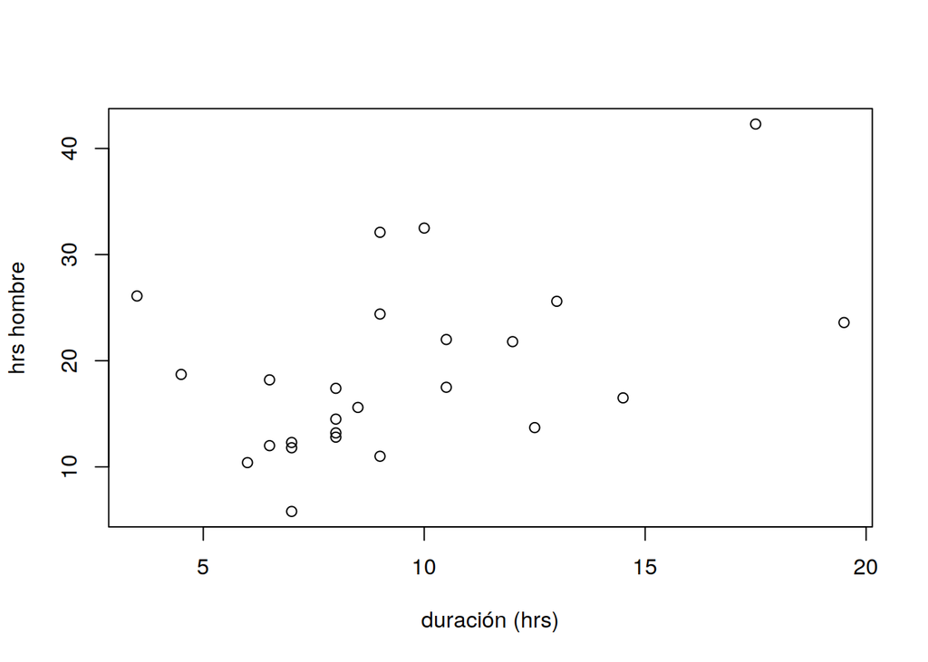

```r
with(nieve,plot(x1,x2, xlab = "duración (hrs)",
                        ylab = "hrs hombre") )
```

```r
cor(nieve)
```

```
##           x1        x2
## x1 1.0000000 0.4631117
## x2 0.4631117 1.0000000
```

7. Recordatorio de descomposición espectral. Para la matriz ${\bf A}$ siguiente, encuentren los eigenvalores y eigenvectores y escriban la descomposición espectral

```r
A <- matrix(c(13,-4,2,-4,13,-2,2,-2,10),nrow=3)
A
```

```
##      [,1] [,2] [,3]
## [1,]   13   -4    2
## [2,]   -4   13   -2
## [3,]    2   -2   10
```

Lo que tenemos que hacer es resolver la ecuación $det({\bf A}-\lambda{\bf I})=0$

Desarrollando el determinante $\det{\begin{pmatrix} 13-\lambda & -4 & 2 \\ -4 & 13-\lambda & -2 \\ 2 & -2 & 10- \lambda\end{pmatrix}}$ que es igual a

$$(13-\lambda)[(13-\lambda)(10-\lambda)-4] + 4[(-4)(10-\lambda)+4] -2[8+2(13-\lambda)] = -\lambda^3+36\lambda^2-405\lambda+1458=0$$

Podemos encontrar las raíces con la función {polyroot}

```r
polyroot(c(1458,-405,36,-1)) #devuelve las ríces complejas
```

```
## [1]  9-0i  9+0i 18+0i
```

```r
Re(polyroot(c(1458,-405,36,-1)))
```

```
## [1]  9  9 18
```

Los eigenvectores son las ${\bf x}$ que satisfacen ${\bf A}{\bf x} = \lambda{\bf x}$. Entonces para $\lambda=18$: nos queda el sistema de ecuaciones:

$$\begin{eqnarray}
13x_1 - 4x_2 + 2x_3 &=& 18 x_1 \\
-4x_1 +13x_2 - 2x_3 &=& 18 x_2 \\
2x_1 - 2x_2 + 10x_3 &=& 18 x_2
\end{eqnarray}$$

Este sistema se simplifica sumando las dos primeras ecuaciones y nos quedan las dos ecuaciones: $x_1 + x_2 = 0$ y $x_1 - x_2 - 4x_3 = 0$ y se simplifica a las dos ecuaciones con tres incógnitas: $x_1 + x_2=0$ y $x_2 + 2x_3=0$. Tomando $x_1=1$ arbitrariamente, una solución es ${\bf x}=(1,-1,1/2)$ y el eigenvector estándarizado asociado a $\lambda=18$ es ${\bf e}=(1,-1,1/2)/\sqrt{9/4}=(2/3,-2/3,1/3)$. Del mismo modo hay que resolver para $\lambda=9$.

Con funciones de R:

```r
eigen(A)
```

```
## eigen() decomposition
## $values
## [1] 18  9  9
##
## $vectors
##            [,1]       [,2]      [,3]
## [1,]  0.6666667 -0.7453560 0.0000000
## [2,] -0.6666667 -0.5962848 0.4472136
## [3,]  0.3333333  0.2981424 0.8944272
```

```r
e1 <- eigen(A)$vectors[,1] #están en el orden dado de los eigenvectores
e2 <- eigen(A)$vectors[,2]
e3 <- eigen(A)$vectors[,3]
#Descomposición espectral de A:
B <- 18*e1%*%t(e1) + 9*e2%*%t(e2)+9*e3%*% t(e3)
round(A-B,10) # son iguales
```

```
##      [,1] [,2] [,3]
## [1,]    0    0    0
## [2,]    0    0    0
## [3,]    0    0    0
```

La generalización de la descomposición espectral para matrices simétricas a matrices rectangulares de $m\times k$ es la descomposición en valor singular. Por ejemplo,

```r
B <- matrix(c(4,3,8,6,8,-9),nrow=2) #matriz de 2x3
B
```

```
##      [,1] [,2] [,3]
## [1,]    4    8    8
## [2,]    3    6   -9
```

```r
svd(B) # descompone la matriz en uDv'
```

```
## $d
## [1] 12.24745 10.95445
##
## $u
##            [,1]      [,2]
## [1,] -0.8944272 0.4472136
## [2,]  0.4472136 0.8944272
##
## $v
##            [,1]       [,2]
## [1,] -0.1825742  0.4082483
## [2,] -0.3651484  0.8164966
## [3,] -0.9128709 -0.4082483
```

```r
svd(B)$u %*% diag(svd(B)$d) %*% t(svd(B)$v) #reproducimos B
```

```
##      [,1] [,2] [,3]
## [1,]    4    8    8
## [2,]    3    6   -9
```

En este caso se puede escribir ${\bf B}= \sum_{i=1}^r \lambda_i{\bf u}_i{\bf v}'={\bf U}{\bf \Lambda}{\bf V}'$ , donde ${\bf U}$ es una matriz ortogonal de $m\times m$ y ${\bf V}$ es una matriz ortogonal de $k\times k$ y hay $min(m,k)$ valores $\lambda_i\geq 0$.